# Hyne Trial : Green Board Data

## 1.5 Board Dimensions

Let's compare the dimension data in the trimmer (f=FlitchDetail, b=BoardDetail), SICK (s=skimage.regionprops), ecoustic (e)YY

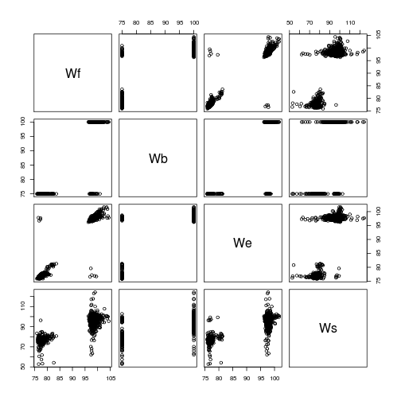

```r
pairs(B[, c("Wf", "Wb", "We", "Ws")])
```

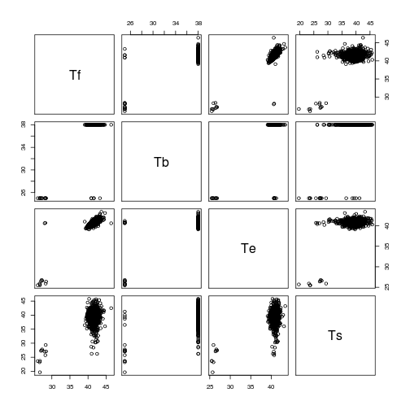

```r
pairs(B[, c("Tf", "Tb", "Te", "Ts")])
```

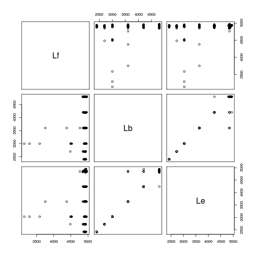

```r
pairs(B[, c("Lf", "Lb", "Le")])
```

```r
imismatch = abs(B$Wf - B$We) > 10 | abs(B$Tf - B$Te) > 10 | abs(B$Lb - B$Le) >
    200
B[imismatch, c("flitchId", "isByproduct", "Wf", "Wb", "Ws", "We", "Tf", "Tb",
    "Ts", "Te", "Lf", "Lb", "Le")]
```

```
##      flitchId isByproduct   Wf Wb     Ws   We   Tf Tb    Ts   Te   Lf   Lb
## 248   1281309           1 97.5 75  85.22 98.4 41.3 38 38.04 40.7 4925 4200
## 358   1281419           1 99.9 75  97.13 97.6 41.3 38 37.41 41.4 4947 4200
## 365   1281426           1 97.3 75  98.31 97.1 28.0 25 27.00 40.6 4763 3600
## 500   1281561           1 97.0 75  97.04 76.6 42.7 38 39.17 40.6 4906 4800
## 516   1281577           1 97.3 75  99.20 79.6 40.7 38 38.09 40.4 4914 4800
## 675   1281736           1 97.3 75  98.53 97.0 42.4 38 43.28 41.1 4910 3600
## 692   1281753           1 98.0 75  94.38 97.8 41.6 38 38.11 41.0 4924 3600
## 736   1281797           1 97.2 75 100.23 97.2 41.2 38 44.60 41.2 4931 4200
## 823   1281884           1 99.5 75  96.10 76.7 41.3 38 40.44 41.3 4872 4800
## 867   1281928           1 98.1 75  94.56 97.2 41.8 38 41.80 40.7 4914 4200
## 1074  1282135           1 98.0 75  94.37 97.6 41.3 38 37.84 40.5 4911 4200
## 1112  1282173           1 98.0 75  94.16 98.4 42.0 38 36.56 40.9 4920 3600
## 1194  1282255           1 77.3 75  72.18 97.2 40.9 25 36.52 40.8 4928 4800
## 1389  1282450           1 77.3 75  72.59 97.7 43.3 25 40.04 40.9 4905 4800
```

[output cut: 27 more lines]

AAAARGGGH. Some 100x40's that the optimiser thought should be re-edged were also trimmed (probably because the do-not-trim logic was based on optimised rather than actual board dimensions) e.g. FlitchId 1282173.

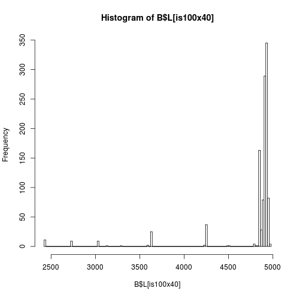

```r
hist(B$L[is100x40], 100)
```

Is log length distinct enough to help identify boards that no good barcode read was extracted from?

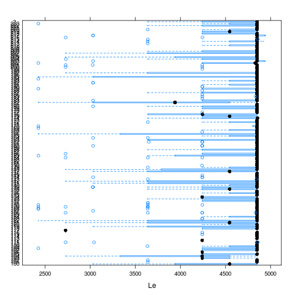

```r
bwplot(as.factor(SWILogNumber) ~ Le, B, subset = is100x40)
```

## 1.6 Board Orientation in SICK Images

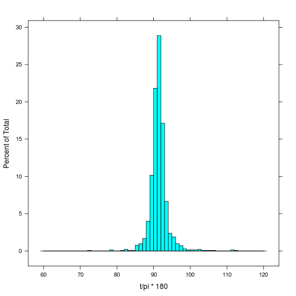

```r
ii = !is.na(B$theta_s)
t = B$theta_s[ii]
t[t < 0] = pi + t[t < 0]
histogram(t/pi * 180, breaks = seq(60, 120))
```

```r
summary(t * 180/pi)
```

```
##    Min. 1st Qu.  Median    Mean 3rd Qu.    Max.
##    72.1    90.4    91.3    91.4    92.2   112.0
```

Assign SWILogNumber to unidentified boards -----------------------------------------'

Based on:

1. sequence
2. untrimmed (FlitchDetail) length
3. time (but apart from limited cases where whole chain flushed no more info than sequence and a lot harder to work with)
4. Saw pattern (see below) but this is pretty tricky

Not much than can be done about the boards 73 boards that passed through while the SICK camera was off (from logs: 161, 110, 159, 101, 184, 178, 120, 122, 116, 118, 106, 102, 175, 121, 183, 129)

```r
plot(1:nrow(B.all), B.all$Lf, cex=0.1)#, xlim=c(0,30))
text(c(1:nrow(B.all)), B.all$Lf+40, B.all$SWILogNumber, cex=0.7)
```

[figure not shown]

```r
# Do this using plot.ly (so zoom-pan-identify works easily):
library(plotly)
py <- plotly()
trace0 <- list(
  #x = B.all$t.trimmer2,
  x = 1:nrow(B.all),
  y = B.all$Lf,
  mode = "markers+text",
  text = B.all$SWILogNumber,
  textposition = "top",
  type = "scatter"
   )
layout <- list(
  #xaxis = list(range = c(1, 15)),
  xaxis = list(range = c(1480, 1580)),
  #yaxis = list(range = c(4600, 5000))
  yaxis = list(range = c(4850, 4980))
)
response <- py$plotly(trace0, kwargs=list(layout=layout, filename="hyne-untrimmed-board-length", fileopt="overwrite"))
response$url
```

```
## [1] "https://plot.ly/~letme1n/1"
```

## 1.7 Board Density, MOE and SWV

```r
library(hexbin)
```

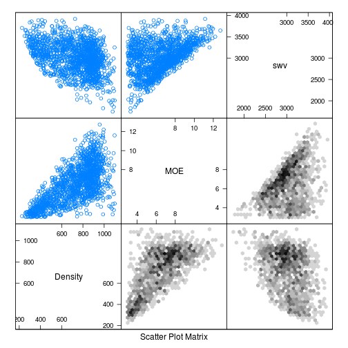

```r
splom(B[, c("Density", "MOE", "swv")], lower.panel = function(x, y, ...) {
    panel.hexbinplot(x, y)
})
```

Hmmm. What green board data have we got to compare this with?

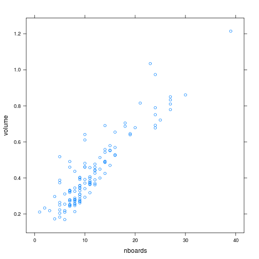

```r
library(plyr)
library(lattice)
L = merge(L, ddply(B, .(SWILogNumber), summarize, nboards = length(SWILogNumber),
    boardVolume = sum(V), boardArea = sum(W * T), avgBoardMOE = sum(MOE * W *
        T)/boardArea, avgBoardDEN = sum(Density * W * T)/boardArea, avgBoardSWV = sum(swv *
        W * T)/boardArea))
L$recFrac = L$boardVolume/L$volume
L$den = L$weight/L$volume
L$MOE = L$SWV^2 * L$den/1e+09
xyplot(volume ~ nboards, L)
```

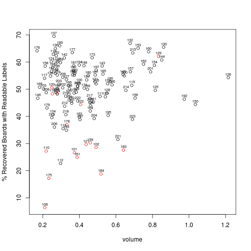

```r
suspect.lognumbers = c(161, 110, 159, 101, 184, 178, 120, 122, 116, 118, 106,
    102, 175, 121, 183, 129)  # logs likely to have boards the SIC camera missed during outage
clr = rep("black", nrow(L))
clr[L$SWILogNumber %in% suspect.lognumbers] = "red"
plot(boardVolume/volume * 100 ~ volume, L, ylab = "% Recovered Boards with Readable Labels",
    col = clr)
text(L$volume, L$boardVolume/L$volume * 100 + 1.2, L$SWILogNumber, cex = 0.6)
```

Why is log 137 the best recovered? All boards from 137 are actual reads from the SICK camera rather than maual assignations.

## 1.8 Average Board Density

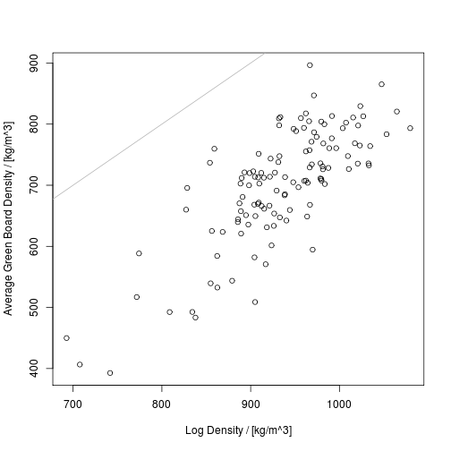

```r
plot(avgBoardDEN ~ den, L, xlab = "Log Density / [kg/m^3]", ylab = "Average Green Board Density / [kg/m^3]")
abline(c(0, 1), col = "grey70")
```

```r
summary(m <- lm(avgBoardDEN ~ den + heartVolFrac, L))
```

```
##
## Call:
## lm(formula = avgBoardDEN ~ den + heartVolFrac, data = L)
##
## Residuals:
##     Min      1Q  Median      3Q     Max
## -160.37  -37.78   -4.74   40.98  159.98
##
## Coefficients:
##              Estimate Std. Error t value Pr(>|t|)
## (Intercept)  -201.413    163.547   -1.23     0.22
## den             0.982      0.152    6.45  2.5e-09 ***
## heartVolFrac  -68.804    107.128   -0.64     0.52
## ---
## Signif. codes:  0 '***' 0.001 '**' 0.01 '*' 0.05 '.' 0.1 ' ' 1
##
## Residual standard error: 60.1 on 120 degrees of freedom
## Multiple R-squared:  0.596,  Adjusted R-squared:  0.589
## F-statistic: 88.4 on 2 and 120 DF,  p-value: <2e-16
```

Why is log density so much higher than average board density? Just due to over representation of inner material?

## 1.9 Average Board SWV

Only look at hitman SWV due to issues with calibre SWV (see `hyne-log.Rmd`).

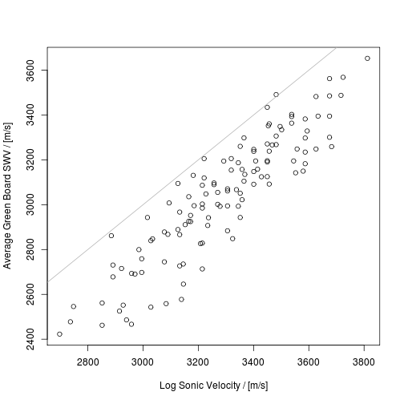

```r
plot(avgBoardSWV ~ SWV, L, xlab = "Log Sonic Velocity / [m/s]", ylab = "Average Green Board SWV / [m/s]")
abline(c(0, 1), col = "grey70")
```

```r
summary(m <- lm(avgBoardSWV ~ SWV, L))
```

```
##
## Call:
## lm(formula = avgBoardSWV ~ SWV, data = L)
##
## Residuals:
##    Min     1Q Median     3Q    Max
## -306.6  -74.1   13.0   75.6  249.3
##
## Coefficients:
##              Estimate Std. Error t value Pr(>|t|)
## (Intercept) -392.2604   148.6353   -2.64   0.0094 **
## SWV            1.0438     0.0451   23.15   <2e-16 ***
## ---
## Signif. codes:  0 '***' 0.001 '**' 0.01 '*' 0.05 '.' 0.1 ' ' 1
##
## Residual standard error: 120 on 120 degrees of freedom
##   (1 observation deleted due to missingness)
## Multiple R-squared:  0.817,  Adjusted R-squared:  0.816
## F-statistic:  536 on 1 and 120 DF,  p-value: <2e-16
```

```r
summary(m <- lm(avgBoardSWV ~ SWV + heartVolFrac, L))
```

```
##
## Call:
## lm(formula = avgBoardSWV ~ SWV + heartVolFrac, data = L)
##
## Residuals:
##    Min     1Q Median     3Q    Max
## -304.7  -72.9   13.7   76.0  248.9
##
## Coefficients:
##               Estimate Std. Error t value Pr(>|t|)
## (Intercept)  -388.1794   151.8441   -2.56    0.012 *
## SWV             1.0413     0.0483   21.57   <2e-16 ***
## heartVolFrac   17.5469   120.2745    0.15    0.884
## ---
## Signif. codes:  0 '***' 0.001 '**' 0.01 '*' 0.05 '.' 0.1 ' ' 1
##
## Residual standard error: 120 on 119 degrees of freedom
##   (1 observation deleted due to missingness)
## Multiple R-squared:  0.817,  Adjusted R-squared:  0.814
## F-statistic:  266 on 2 and 119 DF,  p-value: <2e-16
```

```r
summary(m <- lm(avgBoardSWV ~ SWV + heartVolFrac + den, L))
```

```
##
## Call:
## lm(formula = avgBoardSWV ~ SWV + heartVolFrac + den, data = L)
##
## Residuals:
##    Min     1Q Median     3Q    Max
## -274.0  -73.0   14.5   70.7  242.6
##
## Coefficients:
##               Estimate Std. Error t value Pr(>|t|)
## (Intercept)   387.8216   345.0696    1.12    0.263
## SWV             1.0488     0.0474   22.15   <2e-16 ***
## heartVolFrac -435.7066   216.6704   -2.01    0.047 *
## den            -0.7465     0.2996   -2.49    0.014 *
## ---
## Signif. codes:  0 '***' 0.001 '**' 0.01 '*' 0.05 '.' 0.1 ' ' 1
##
## Residual standard error: 118 on 118 degrees of freedom
##   (1 observation deleted due to missingness)
## Multiple R-squared:  0.826,  Adjusted R-squared:  0.822
## F-statistic:  187 on 3 and 118 DF,  p-value: <2e-16
```

```r
summary(m <- lm(avgBoardSWV ~ SWV + heartVolFrac + avgBoardDEN, L))
```

```
##
## Call:
## lm(formula = avgBoardSWV ~ SWV + heartVolFrac + avgBoardDEN,
##     data = L)
##
## Residuals:
##    Min     1Q Median     3Q    Max
## -308.9  -71.5   12.0   77.9  216.5
##
## Coefficients:
##               Estimate Std. Error t value Pr(>|t|)
## (Intercept)   350.2997   225.3872    1.55    0.123
## SWV             0.9817     0.0474   20.73  < 2e-16 ***
## heartVolFrac -359.0692   143.6403   -2.50    0.014 *
## avgBoardDEN    -0.6519     0.1544   -4.22  4.8e-05 ***
## ---
## Signif. codes:  0 '***' 0.001 '**' 0.01 '*' 0.05 '.' 0.1 ' ' 1
##
## Residual standard error: 112 on 118 degrees of freedom
##   (1 observation deleted due to missingness)
## Multiple R-squared:  0.841,  Adjusted R-squared:  0.837
## F-statistic:  208 on 3 and 118 DF,  p-value: <2e-16
```

## 1.10 Average Board MOE

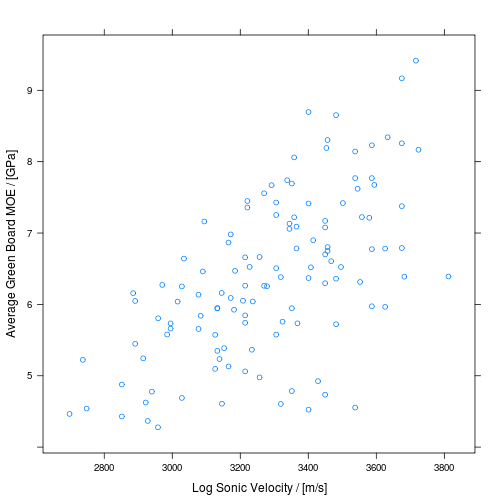

```r
xyplot(avgBoardMOE ~ SWV, L, xlab = "Log Sonic Velocity / [m/s]", ylab = "Average Green Board MOE / [GPa]")
```

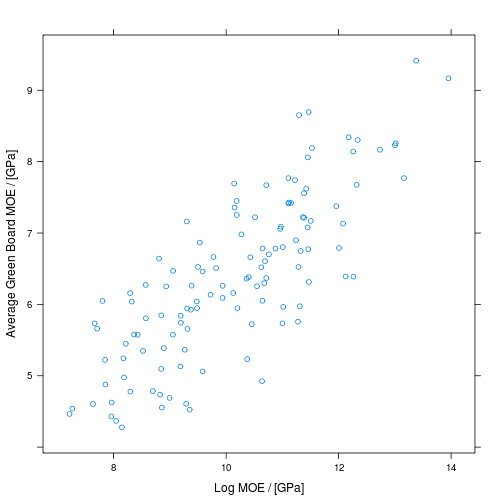

```r
xyplot(avgBoardMOE ~ MOE, L, xlab = "Log MOE / [GPa]", ylab = "Average Green Board MOE / [GPa]")
```

```r
summary(m <- lm(avgBoardMOE ~ MOE, L))
```

```
##
## Call:
## lm(formula = avgBoardMOE ~ MOE, data = L)
##
## Residuals:
##     Min      1Q  Median      3Q     Max
## -1.7695 -0.4290 -0.0208  0.4440  1.5546
##
## Coefficients:
##             Estimate Std. Error t value Pr(>|t|)
## (Intercept)   0.1728     0.4293     0.4     0.69
## MOE           0.6130     0.0419    14.6   <2e-16 ***
## ---
## Signif. codes:  0 '***' 0.001 '**' 0.01 '*' 0.05 '.' 0.1 ' ' 1
##
## Residual standard error: 0.684 on 120 degrees of freedom
##   (1 observation deleted due to missingness)
## Multiple R-squared:  0.64,   Adjusted R-squared:  0.637
## F-statistic:  214 on 1 and 120 DF,  p-value: <2e-16
```

```r
summary(m <- lm(avgBoardMOE ~ SWV, L))
```

```
##
## Call:
## lm(formula = avgBoardMOE ~ SWV, data = L)
##
## Residuals:
##     Min      1Q  Median      3Q     Max
## -2.5406 -0.6021  0.0266  0.6075  1.9924
##
## Coefficients:
##              Estimate Std. Error t value Pr(>|t|)
## (Intercept) -3.018852   1.125760   -2.68   0.0084 **
## SWV          0.002859   0.000341    8.37  1.2e-13 ***
## ---
## Signif. codes:  0 '***' 0.001 '**' 0.01 '*' 0.05 '.' 0.1 ' ' 1
##
## Residual standard error: 0.906 on 120 degrees of freedom
##   (1 observation deleted due to missingness)
## Multiple R-squared:  0.369,  Adjusted R-squared:  0.364
## F-statistic: 70.1 on 1 and 120 DF,  p-value: 1.21e-13
```

```r
summary(m <- lm(avgBoardMOE ~ MOE + den, L))
```

```
##
## Call:
## lm(formula = avgBoardMOE ~ MOE + den, data = L)
##
## Residuals:
##     Min      1Q  Median      3Q     Max
## -1.6751 -0.3836  0.0199  0.3998  1.5973
##
## Coefficients:
##              Estimate Std. Error t value Pr(>|t|)
## (Intercept) -2.020827   0.855673   -2.36    0.020 *
## MOE          0.582068   0.042009   13.86   <2e-16 ***
## den          0.002683   0.000914    2.93    0.004 **
## ---
## Signif. codes:  0 '***' 0.001 '**' 0.01 '*' 0.05 '.' 0.1 ' ' 1
##
## Residual standard error: 0.663 on 119 degrees of freedom
##   (1 observation deleted due to missingness)
## Multiple R-squared:  0.665,  Adjusted R-squared:  0.659
## F-statistic:  118 on 2 and 119 DF,  p-value: <2e-16
```

```r
summary(m <- lm(avgBoardMOE ~ SWV + den, L))
```

```
##
## Call:
## lm(formula = avgBoardMOE ~ SWV + den, data = L)
##
## Residuals:
##     Min      1Q  Median      3Q     Max
## -1.7102 -0.4269  0.0263  0.4409  1.6067
##
## Coefficients:
##              Estimate Std. Error t value Pr(>|t|)
## (Intercept) -1.39e+01   1.39e+00  -10.00   <2e-16 ***
## SWV          3.55e-03   2.64e-04   13.43   <2e-16 ***
## den          9.20e-03   9.36e-04    9.83   <2e-16 ***
## ---
## Signif. codes:  0 '***' 0.001 '**' 0.01 '*' 0.05 '.' 0.1 ' ' 1
##
## Residual standard error: 0.676 on 119 degrees of freedom
##   (1 observation deleted due to missingness)
## Multiple R-squared:  0.652,  Adjusted R-squared:  0.646
## F-statistic:  111 on 2 and 119 DF,  p-value: <2e-16
```

```r
summary(m <- lm(avgBoardMOE ~ MOE + heartVolFrac, L))
```

```
##
## Call:
## lm(formula = avgBoardMOE ~ MOE + heartVolFrac, data = L)
##
## Residuals:
##     Min      1Q  Median      3Q     Max
## -1.6921 -0.4323 -0.0388  0.4639  1.5095
##
## Coefficients:
##              Estimate Std. Error t value Pr(>|t|)
## (Intercept)    0.6901     0.4538    1.52   0.1310
## MOE            0.6024     0.0409   14.73   <2e-16 ***
## heartVolFrac  -1.8024     0.6258   -2.88   0.0047 **
## ---
## Signif. codes:  0 '***' 0.001 '**' 0.01 '*' 0.05 '.' 0.1 ' ' 1
##
## Residual standard error: 0.664 on 119 degrees of freedom
##   (1 observation deleted due to missingness)
## Multiple R-squared:  0.664,  Adjusted R-squared:  0.658
## F-statistic:  117 on 2 and 119 DF,  p-value: <2e-16
```

```r
summary(m <- lm(avgBoardMOE ~ SWV + heartVolFrac, L))
```

```
##
## Call:
## lm(formula = avgBoardMOE ~ SWV + heartVolFrac, data = L)
##
## Residuals:
##     Min      1Q  Median      3Q     Max
## -1.7395 -0.4653 -0.0909  0.6157  1.5627
##
## Coefficients:
##               Estimate Std. Error t value Pr(>|t|)
## (Intercept)  -4.372616   0.932252   -4.69  7.3e-06 ***
## SWV           0.003673   0.000296   12.39  < 2e-16 ***
## heartVolFrac -5.820696   0.738429   -7.88  1.7e-12 ***
## ---
## Signif. codes:  0 '***' 0.001 '**' 0.01 '*' 0.05 '.' 0.1 ' ' 1
##
## Residual standard error: 0.737 on 119 degrees of freedom
##   (1 observation deleted due to missingness)
## Multiple R-squared:  0.585,  Adjusted R-squared:  0.578
## F-statistic:   84 on 2 and 119 DF,  p-value: <2e-16
```

```r
summary(m <- lm(avgBoardMOE ~ MOE + heartVolFrac + den, L))
```

```
##
## Call:
## lm(formula = avgBoardMOE ~ MOE + heartVolFrac + den, data = L)
##
## Residuals:
##     Min      1Q  Median      3Q     Max
## -1.6762 -0.3990  0.0018  0.4549  1.5583
##
## Coefficients:
##              Estimate Std. Error t value Pr(>|t|)
## (Intercept)  -0.88260    1.82486   -0.48     0.63
## MOE           0.58951    0.04339   13.58   <2e-16 ***
## heartVolFrac -0.86562    1.22505   -0.71     0.48
## den           0.00159    0.00179    0.89     0.38
## ---
## Signif. codes:  0 '***' 0.001 '**' 0.01 '*' 0.05 '.' 0.1 ' ' 1
##
## Residual standard error: 0.665 on 118 degrees of freedom
##   (1 observation deleted due to missingness)
## Multiple R-squared:  0.666,  Adjusted R-squared:  0.658
## F-statistic: 78.4 on 3 and 118 DF,  p-value: <2e-16
```

```r
summary(m <- lm(avgBoardMOE ~ SWV + heartVolFrac + den, L))
```

```
##
## Call:
## lm(formula = avgBoardMOE ~ SWV + heartVolFrac + den, data = L)
##
## Residuals:
##     Min      1Q  Median      3Q     Max
## -1.6978 -0.4246  0.0138  0.4886  1.5708
##
## Coefficients:
##               Estimate Std. Error t value Pr(>|t|)
## (Intercept)  -1.30e+01   1.99e+00   -6.52  1.8e-09 ***
## SWV           3.59e-03   2.73e-04   13.15  < 2e-16 ***
## heartVolFrac -7.98e-01   1.25e+00   -0.64     0.52
## den           8.27e-03   1.73e-03    4.79  4.9e-06 ***
## ---
## Signif. codes:  0 '***' 0.001 '**' 0.01 '*' 0.05 '.' 0.1 ' ' 1
##
## Residual standard error: 0.678 on 118 degrees of freedom
##   (1 observation deleted due to missingness)
## Multiple R-squared:  0.653,  Adjusted R-squared:  0.644
## F-statistic:   74 on 3 and 118 DF,  p-value: <2e-16
```

```r
summary(m <- lm(avgBoardMOE ~ SWV + heartVolFrac + den + avgBoardDEN, L))
```

```
##
## Call:
## lm(formula = avgBoardMOE ~ SWV + heartVolFrac + den + avgBoardDEN,
##     data = L)
##
## Residuals:
##     Min      1Q  Median      3Q     Max
## -1.3371 -0.3600  0.0469  0.4124  1.0955
##
## Coefficients:
##               Estimate Std. Error t value Pr(>|t|)
## (Intercept)  -1.35e+01   1.57e+00   -8.60  4.3e-14 ***
## SWV           4.35e-03   2.33e-04   18.63  < 2e-16 ***
## heartVolFrac -1.11e+00   9.87e-01   -1.12     0.27
## den           6.60e-04   1.63e-03    0.40     0.69
## avgBoardDEN   7.47e-03   8.80e-04    8.49  7.7e-14 ***
## ---
## Signif. codes:  0 '***' 0.001 '**' 0.01 '*' 0.05 '.' 0.1 ' ' 1
##
## Residual standard error: 0.535 on 117 degrees of freedom
##   (1 observation deleted due to missingness)
## Multiple R-squared:  0.785,  Adjusted R-squared:  0.778
## F-statistic:  107 on 4 and 117 DF,  p-value: <2e-16
```

## 1.11 Saw Patterns

Plot board centroids:

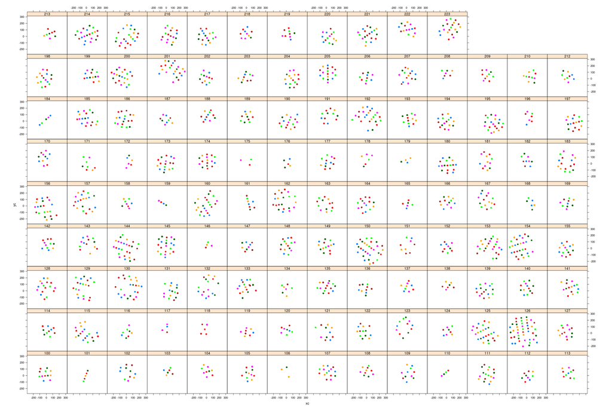

```r
library(RODBC)
ch = odbcConnect("HYNE", "sa", "password12")
C = sqlQuery(ch, "select *, \n             (i1-42)*0.7071*20.0 - (i2-42)*0.2588*20.0 as x,\n(i1-42)*0.7071*20.0 + (i2-42)*0.9659*20.0 as y\n             from SICK_barcodes")  # where boardCentroidX_mm is not null')
C$xc = C$boardCentroidX_mm
C$yc = C$boardCentroidY_mm

# xyplot(y ~ x | as.factor(SWILogNumber), C, group=imageId, aspect='iso',
# pch=19, subset=imageId==721) xyplot(yc ~ xc | as.factor(SWILogNumber), C,
# group=imageId, aspect='iso', pch=19, subset=imageId==721)

# xyplot(y ~ x | as.factor(SWILogNumber), C, group=imageId, aspect='iso',
# pch=19, type='b')#, subset=SWILogNumber==150)
xyplot(yc ~ xc | as.factor(SWILogNumber), C, group = imageId, aspect = "iso",
    pch = 19, type = "b")  #, subset=SWILogNumber==150)
```

SICK camera scale factor

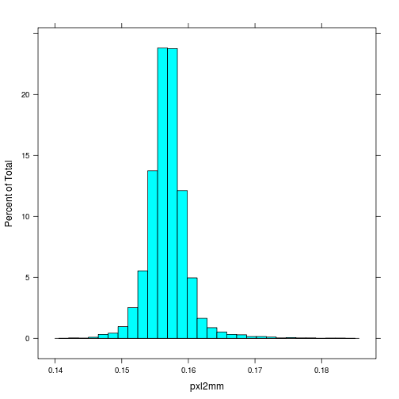

```r
histogram(~pxl2mm, nint = 30, C)
```

```r
summary(C$pxl2mm)
```

```
##    Min. 1st Qu.  Median    Mean 3rd Qu.    Max.    NA's
##     0.1     0.2     0.2     0.2     0.2     0.2     520
```

Does SICK scale factor vary through time?

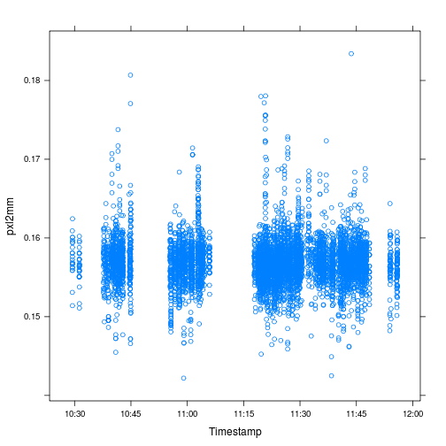

```r
library(RODBC)
ch = odbcConnect("HYNE", "sa", "password12")
F = sqlQuery(ch, "select b.pxl2mm, i.Timestamp from SICK_images as i left join SICK_barcodes as b on b.imageId=i.id where nboards>0")
xyplot(pxl2mm ~ Timestamp, F)
```

```r
library(changepoint)
summary(m <- cpt.mean(F$pxl2mm[is.finite(F$pxl2mm)], method = "PELT"))
```

```
## Changepoint type      : Change in mean
## Method of analysis    : PELT
## Test Statistic  : Normal
## Type of penalty       : SIC with value, 8.761
## Maximum no. of cpts   : Inf
## Changepoint Locations :
```

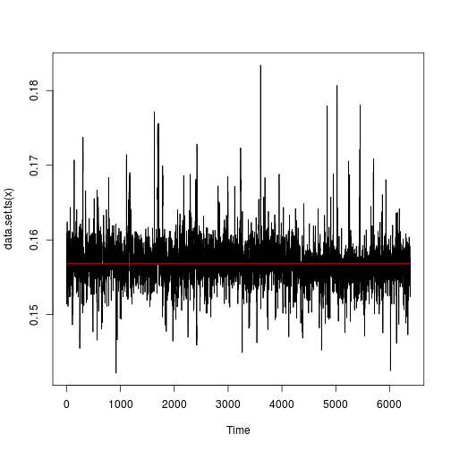

```r
plot(m)  # no evidence for a shift in mean
```

Not so much.

The major outlier is image 1187, the image with two boards in one lug. The boards are from two different logs (160, 153) consequently the relative positions are meaningless.

The next worst is 1626. Based on two barcodes. Manual calcs agree, as do calcs based on individual barcodes.

Board orientation w.r.t log csys. Ideally 4 peaks separated by 90 deg. Expect the cant direction (two of the peaks separated by 180 deg) to be more popular.

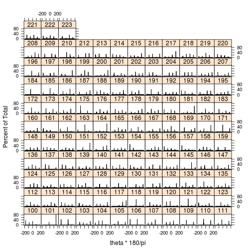

```r
histogram(~theta * 180/pi | as.factor(SWILogNumber), nint = 100, C)
```

## 1.12 Recommendations

To make merge different board data streams easier:

- include lug id explicitly (is this even possible? if so, who needs to action?)
- leave tipples running and pass byproduct boards back through (though without trimming labelled end) or disable the byproduct option in the optimiser (so PLC knows about all boards)

Assigning log numbers to boards with lost/unreadable labels would be much easier if

- either the chain were flushed between logs
- or logs were trimmed, as squarely as possible, to random but distinctly different lengths (this still dosn't help with short, waney outer boards though)

If the green and dry board data is to be merged, then to avoid extra effort need to make sure that as many barcodes as possible are read from each dry board SICK image.